# Learning Principles

A key assumption in machine learning is that the training and test set come from the same probability distribution (i.i.d), however, for practical applications it's not valid. In this post, we'll go through various learning principles that underpin machine learning systems. We'll start with models trained on average with Empirical Risk Minimization, then we'll see how to formulate loss function in the worst case with Distributionally Robust Optimization. Lastly, we'll look into how objective function can be derived in the mold of Adaptive Risk Minimization.

## I. Introduction

A traditional paradigm for training machine learning models is to minimize the average loss for a given training set, with the main objective of achieving a high accuracy on a test set that came from the same probability distribution with the previously given training set. These models can be accurate in the average case but perform poorly when they are tested in the worst-case scenarios. They rely on spurious correlations (i.e. misleading heuristics that work for most training examples but do not always hold). Various models that learn these correlations can be accurate on average on an i.i.d test set but provide high errors on a group of data where the correlations are violated.

Models are trained in worst-case scenarios over a group of training data to help in alleviating these spurious correlations. The previously mentioned training procedure can be seen as an instance of Distributionally Robust Optimization (DRO), which optimizes for the worst-case loss over potential test distributions. Previous work on DRO has focused on models that cannot approach zero training loss such as generative models or convex predictive models with limited capacity. The issue with directly optimizing with DRO to overparameterized models is that if a model achieves zero training loss then it is optimal on both worst-case (DRO) and the average training objectives. When we are in the vanishing training loss regime, the model trained with DRO performed similarly to the one trained on average with Empirical Risk minimization, both models have high average test accuracies and worst-group training accuracies but low worst-group test accuracies, the generalization gap is small on average but large for the worst group. For models that are strongly regularized with DRO, when they do not attain vanishing training loss, they can perform better than regularized and unregularized ERM models. Several tips and tricks are applied to achieve the aforementioned result (i.e. l2 penalties, early stopping, and group adjustment that minimize a risk measure that accounts for the differences in generalization gap between groups)[1].

A key assumption within several frameworks such as domain generalization is that the training data is available in domains and distribution at test time will represent new domains. To create training domains in practice is generally achieved by using meta-data which exists for commonly used datasets. This domain assumption applies to a wide range of realistic distribution shift problems. Previous benchmarks for domain generalization and similar settings are centered around invariances (i.e. in these benchmarks there is a consistent input-output relationship across all domains and the main goal is to learn this relationship while dismissing the spurious correlation within the domains). Previous methods aim for generalization to shifts by discovering this relationship, through various techniques such as robust optimization and invariant feature space. These methods are preferable in that they make minimal assumptions about the information provided at test time, in particular, they don't require test labels and the learned model can be immediately applied to predict a single point. These methods have limitations in dealing with problems where the input-output relationship varies across domains[2].

## II. ERM

The objective function for empirical risk minimization can be derive as follow [1]:

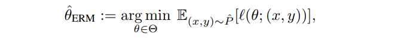

## III. DRO

For distributionally robust optimization we use [1]:

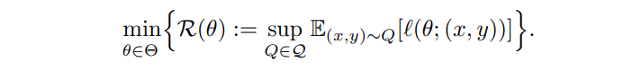

## IV. Group DRO

Similarly for Group Distributionally Robust Optimization we have [1]:

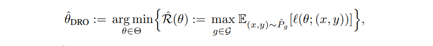

## V. ARM

Lastly the Adaptive Risk Minimization objective can be formulate as follow [2] :

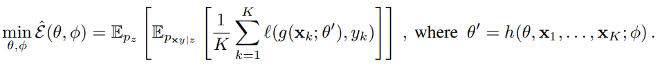

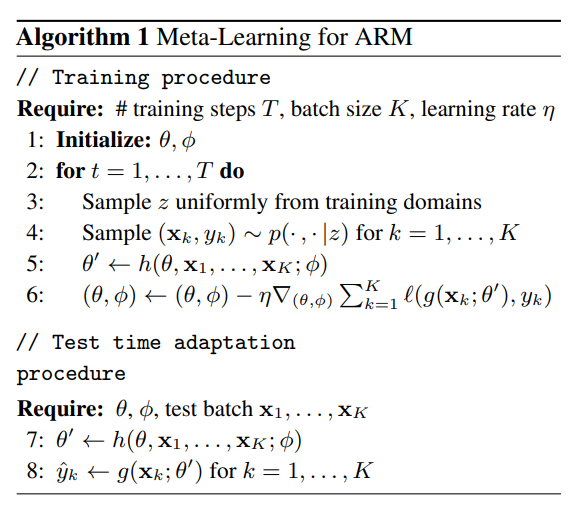

Meta learning algorithm for Adaptive Risk Minimization[2]

## VI. References

1. Shiori Sagawa and Pang Wei Koh and Tatsunori B. Hashimoto and Percy Liang. Distributionally Robust Neural Networks For Group Shifts : On the Importance of Regularization for the Worst Case Generalization. International Conference on Learning Representation, 2020
2. Marvin Zhang and Henrik Marklund and Nikita Dhawan and Abhishek Gupta and Sergey Levine and Chelsea Finn. Adaptive Risk Minimization: Learning to Adapt to Domain Shift. Arxiv, 2021